# Communicate Data Findings :Prosper Loan Data

## Investigation Overview

> In this analysis, I mainly focus on these questions:

> What influence the Borrower Rate.

> Do their personal financial situation influence their borrower rates.

## Dataset Overview

> Prosper is San Francisco based peer-to-peer(P2P) lending company. PSP lending is a industry that matching and facilitating individuals borrowers and lenders. This kind of financial service is generally cheaper than traditional established financial institutions. For lender, this kind of platform generate higher return than saving or long-term investment in banks, and they also provide credit screening services. For borrowers, it’s easier to lend loan from a P2P platform, the administration process is less exhausting and less time consuming.

> This dataset is provided by Udacity. It contains 113936 data entries and 81 variables. Each entry contains all the necessary information about a loan. You can access the data dictionary via the link: https://docs.google.com/spreadsheets/d/1gDyi_L4UvIrLTEC6Wri5nbaMmkGmLQBk-Yx3z0XDEtI/edit#gid=0

```python
# import all packages and set plots to be embedded inline
import numpy as np
import pandas as pd
import matplotlib.pyplot as plt
import seaborn as sb

%matplotlib inline

# suppress warnings from final output
import warnings
warnings.simplefilter("ignore")
```

```python
# load in the dataset into a pandas dataframe
df1 = pd.read_csv("/Users/Q/Documents/UdacityDataAnalyst/Project5/loan_final.csv")
```

```python
df1.head()
```

|  | Unnamed: 0 | ProsperScore | CreditScore | EstimatedLoss | EstimatedReturn | StatedMonthlyIncome | DebtToIncomeRatio | LoanOriginalAmount | BorrowerRate | RevolvingCreditBalance | LP_NetPrincipalLoss | OpenCreditLines |
| --- | --- | --- | --- | --- | --- | --- | --- | --- | --- | --- | --- | --- |
| 0 | 1 | 7.0 | 689.5 | 0.0249 | 0.05470 | 6125.000000 | 0.18 | 10000 | 0.0920 | 3989.0 | 0.0 | 14.0 |
| 1 | 3 | 9.0 | 809.5 | 0.0249 | 0.06000 | 2875.000000 | 0.15 | 10000 | 0.0974 | 1444.0 | 0.0 | 5.0 |
| 2 | 4 | 4.0 | 689.5 | 0.0925 | 0.09066 | 9583.333333 | 0.26 | 15000 | 0.2085 | 6193.0 | 0.0 | 19.0 |
| 3 | 5 | 10.0 | 749.5 | 0.0449 | 0.07077 | 8333.333333 | 0.36 | 15000 | 0.1314 | 62999.0 | 0.0 | 17.0 |
| 4 | 6 | 2.0 | 689.5 | 0.1275 | 0.11070 | 2083.333333 | 0.27 | 3000 | 0.2712 | 5812.0 | 0.0 | 7.0 |

> Note that the above cells have been set as "Skip"-type slides. That means that when the notebook is rendered as http slides, those cells won't show up.

## Correlation matrix

> I used Correlation matrix and Scatter plot to explore the relationship between variables.

> It seems that both Prosper score and Credit score have strong negative relationship with Borrower Rate. Borrowers with higher Prosper score and Credit score are able to borrow with lower cost (borrower rate).

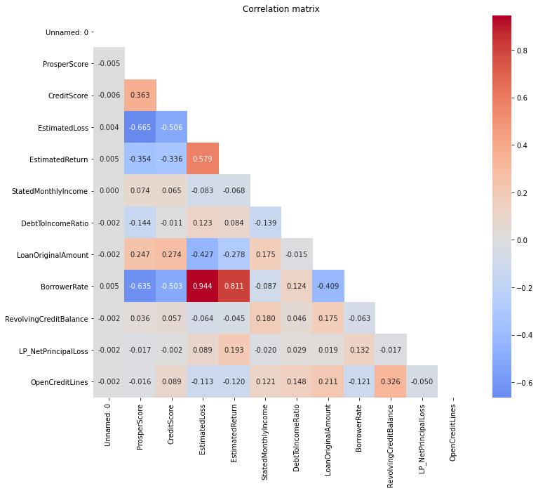

```python
# plot correlation matrix
plt.figure(figsize = [12,10])

mask = np.zeros_like(df1.corr(), dtype=np.bool)
mask[np.triu_indices_from(mask)] = True

sb.heatmap(df1.corr(), annot = True, fmt = '.3f', cmap = 'coolwarm', center = 0, mask=mask)
plt.title('Correlation matrix');
```

# The relationship between BorrowerRate and Credit scores & Prosper Scores

> We can see that the best borrowers with high ProsperScore&Creditscore have lower Borrower Rate. Many borrowers with high Prosper Score can borrowe at rate that is lover than 0.25!

> In general borrowers with higher Prosper Score also have high Credit Score

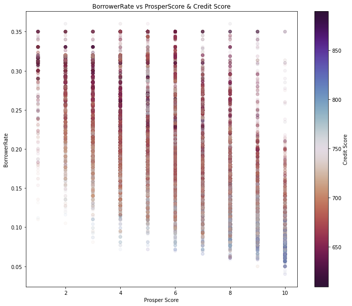

```python
# Scatter plot : The relationship between BorrowerRate and Credit scores & Prosper Scores
plt.figure(figsize = [12,10])
plt.scatter(data=df1, x='ProsperScore', y='BorrowerRate', c='CreditScore', cmap='twilight_shifted_r', alpha=0.05);
cbar = plt.colorbar(label='Credit Score')
cbar.solids.set(alpha=1)
plt.title('BorrowerRate vs ProsperScore & Credit Score');
plt.xlabel('Prosper Score')
plt.ylabel('BorrowerRate');
```

## The relationship between BorrowerRate and Credit scores & EstimatedLoss

> Estimated Loss has a strong positive relationship with borrower rate. And In general, borrower with good Credit Score have lower Estimated loss and can borrow at a lower rate

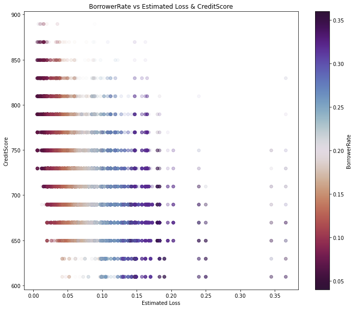

```python
plt.figure(figsize = [12,10])
plt.scatter(data=df1, x='EstimatedLoss', y='CreditScore', c='BorrowerRate', cmap='twilight_shifted_r', alpha=0.05);
cbar = plt.colorbar(label='BorrowerRate')
cbar.solids.set(alpha=1)
plt.title('BorrowerRate vs Estimated Loss & CreditScore');
plt.xlabel('Estimated Loss')
plt.ylabel('CreditScore');
```

> Once you're ready to finish your presentation, check your output by using nbconvert to export the notebook and set up a server for the slides. From the terminal or command line, use the following expression:

> > `jupyter nbconvert <file_name>.ipynb --to slides --post serve --template output_toggle`

> This should open a tab in your web browser where you can scroll through your presentation. Sub-slides can be accessed by pressing 'down' when viewing its parent slide. Make sure you remove all of the quote-formatted guide notes like this one before you finish your presentation!